# Statistical Analysis

2022-10-04

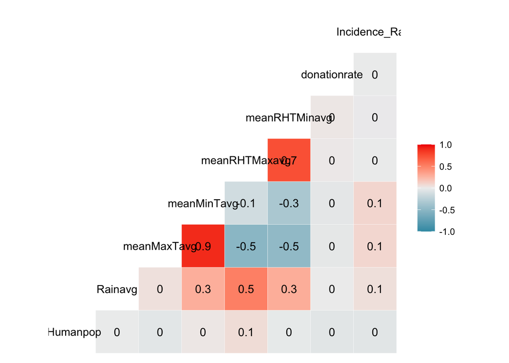

| Humanpop | -0.0448032 |
| --- | --- |
| Rainavg | 0.0526361 |
| meanMaxTavg | 0.0930843 |
| meanMinTavg | 0.0959326 |
| meanRHTMaxavg | -0.0055580 |
| meanRHTMinavg | -0.0066230 |
| donationrate | -0.0057572 |

| Population | -0.0448032 |
| --- | --- |
| Rainfall | 0.0526361 |
| Temperature | 0.0970365 |
| Humidity | -0.0064700 |
| Donation_Rate | -0.0057572 |
| Incidence_Rate | 1.0000000 |

A correlation of -1.0 indicates a perfect negative correlation, and a correlation of 1.0 indicates a perfect positive correlation. If the correlation coefficient is greater than zero, it is a positive relationship. Conversely, if the value is less than zero, it is a negative relationship.

# PCA

Summary of PCA data

|  | PC1 | PC2 | PC3 | PC4 | PC5 | PC6 |
| --- | --- | --- | --- | --- | --- | --- |
| Standard deviation | 1.502598 | 1.180189 | 1.061516 | 0.8773006 | 0.5452621 | 0.3944232 |
| Proportion of Variance | 0.376300 | 0.232140 | 0.187800 | 0.1282800 | 0.0495500 | 0.0259300 |
| Cumulative Proportion | 0.376300 | 0.608440 | 0.796240 | 0.9245200 | 0.9740700 | 1.0000000 |

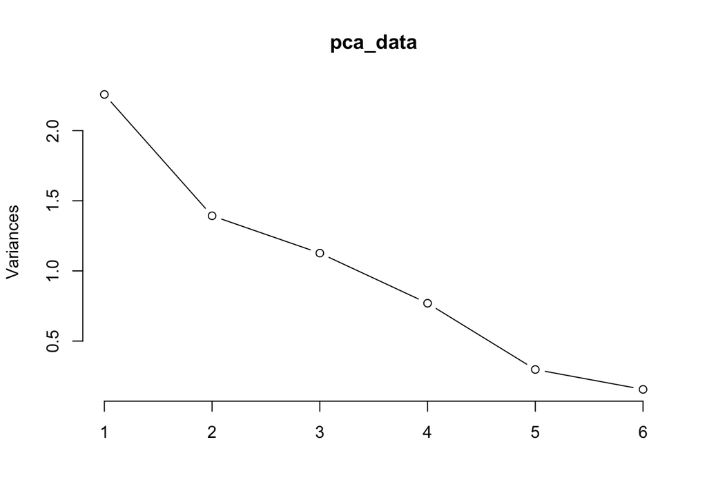

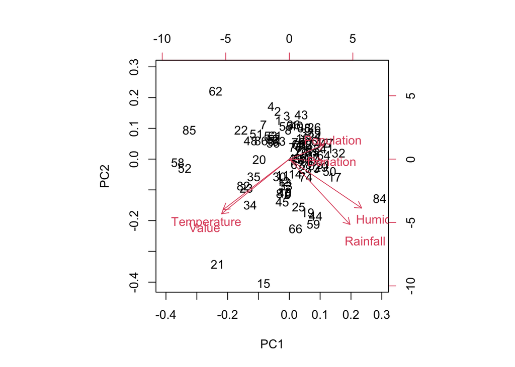

# Clusters

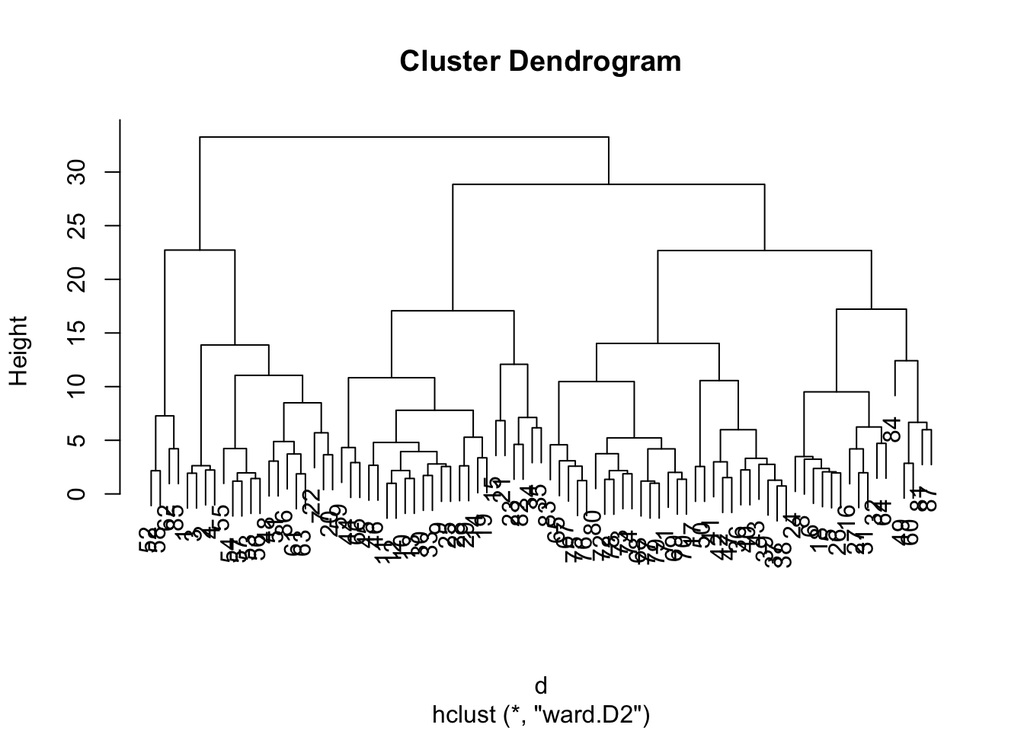

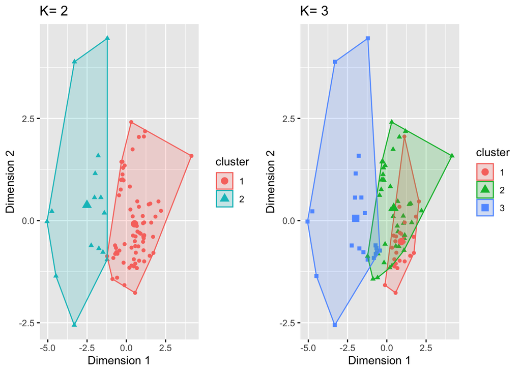

# Negative bionomial

Summary Table

[output not shown]

```
## [1] "Mean of IR 1e-04"
```

```
## [1] "Variance of IR 2e-04"
```

```
## [1] "Variance Ratio 0.014"
```

# Summary stats

```
##
## Call:
## glm(formula = Donation ~ Value, family = "poisson", data = nb_data)
##
## Deviance Residuals:
##     Min       1Q   Median       3Q      Max
## -0.0172  -0.0172  -0.0172  -0.0172   5.8348
##
## Coefficients:
##             Estimate Std. Error z value Pr(>|z|)
## (Intercept)  -8.8181     0.1291 -68.304   <2e-16 ***
## Value       -12.0899   451.6854  -0.027    0.979
## ---
## Signif. codes:  0 '***' 0.001 '**' 0.01 '*' 0.05 '.' 0.1 ' ' 1
##
## (Dispersion parameter for poisson family taken to be 1)
##
##     Null deviance: 1086.8  on 408479  degrees of freedom
## Residual deviance: 1085.9  on 408478  degrees of freedom
## AIC: 1196
##
## Number of Fisher Scoring iterations: 20
```

```
##
## Call:
## glm.nb(formula = Donation ~ Value, data = nb_data, init.theta = 0.0001664230301,
##     link = log)
##
## Deviance Residuals:
##      Min        1Q    Median        3Q       Max
## -0.01455  -0.01455  -0.01455  -0.01455   1.73504
##
## Coefficients:
##              Estimate Std. Error z value Pr(>|z|)
## (Intercept)   -8.8181     0.1775 -49.691   <2e-16 ***
## Value        -14.0899  1227.7925  -0.011    0.991
## ---
## Signif. codes:  0 '***' 0.001 '**' 0.01 '*' 0.05 '.' 0.1 ' ' 1
##
## (Dispersion parameter for Negative Binomial(2e-04) family taken to be 1)
##
##     Null deviance: 176.76  on 408479  degrees of freedom
## Residual deviance: 176.09  on 408478  degrees of freedom
## AIC: 1066.2
##
## Number of Fisher Scoring iterations: 2
##
##
##               Theta:  0.0001664
##           Std. Err.:  2.28e-05
##
##  2 x log-likelihood:  -1060.2090000
```

```
##
## Call:
## glm.nb(formula = Donation ~ Value + Temperature + Humidity +
##     Rainfall, data = nb_data, init.theta = 0.0002056282371, link = log)
##
## Deviance Residuals:
##      Min        1Q    Median        3Q       Max
## -0.02620  -0.01680  -0.01451  -0.01189   1.62590
##
## Coefficients:
##               Estimate Std. Error z value Pr(>|z|)
## (Intercept) -1.788e+01  2.754e+00  -6.494 8.37e-11 ***
## Value       -1.870e+01  1.032e+04  -0.002  0.99855
## Temperature  8.277e-02  3.738e-02   2.214  0.02680 *
## Humidity     1.113e-01  3.470e-02   3.207  0.00134 **
## Rainfall    -3.392e-03  2.594e-03  -1.308  0.19104
## ---
## Signif. codes:  0 '***' 0.001 '**' 0.01 '*' 0.05 '.' 0.1 ' ' 1
##
## (Dispersion parameter for Negative Binomial(2e-04) family taken to be 1)
##
##     Null deviance: 195.40  on 408479  degrees of freedom
## Residual deviance: 185.14  on 408475  degrees of freedom
## AIC: 1060.1
##
## Number of Fisher Scoring iterations: 1
##
##
##               Theta:  0.0002056
##           Std. Err.:  2.99e-05
##
##  2 x log-likelihood:  -1048.1400000
```

```
##
## Call:
## glm.nb(formula = Donation ~ ., data = nb_data, init.theta = 0.0005001788937,
##     link = log)
##
## Deviance Residuals:
##      Min        1Q    Median        3Q       Max
## -0.04694  -0.01864  -0.00955  -0.00468   1.80303
##
## Coefficients:
##               Estimate Std. Error z value Pr(>|z|)
## (Intercept)  1.067e+03  1.636e+02   6.523 6.89e-11 ***
## Year        -5.398e-01  8.155e-02  -6.620 3.60e-11 ***
## Rainfall    -3.799e-03  2.490e-03  -1.526 0.127059
## Temperature  8.352e-02  3.470e-02   2.407 0.016101 *
## Humidity     1.155e-01  3.239e-02   3.564 0.000365 ***
## Value       -2.249e+01  8.085e+04   0.000 0.999778
## ---
## Signif. codes:  0 '***' 0.001 '**' 0.01 '*' 0.05 '.' 0.1 ' ' 1
##
## (Dispersion parameter for Negative Binomial(5e-04) family taken to be 1)
##
##     Null deviance: 282.71  on 408479  degrees of freedom
## Residual deviance: 215.99  on 408474  degrees of freedom
## AIC: 1004.3
##
## Number of Fisher Scoring iterations: 1
##
##
##               Theta:  5e-04
##           Std. Err.:  0.000131
##
##  2 x log-likelihood:  -990.333000
```

```
##              df      AIC
## pois          2 1196.031
## negb          3 1066.209
## negb_all      7 1004.333
## negb_weather  6 1060.140
```

AIC: The Akaike information criterion (AIC) is an information-theoretic measure that describes the quality of a model. A model with a low AIC is characterized by low complexity and a good fit.

Median: Since the median deviance residual is close to zero, this means that our model is not biased in one direction (i.e. the out come is neither over- nor underestimated).

Dispersion Parameter: or Theta simply indicates whether a distribution is wide or narrow. The GLM function can use a dispersion parameter to model the variability.

Null deviance: A low null deviance implies that the data can be modeled well merely using the intercept. If the null deviance is low, you should consider using few features for modeling the data. if the null deviance is high, which means it makes sense to use more than a single parameter for fitting the model.

Residual deviance: A low residual deviance implies that the model you have trained is appropriate.

Degree of freedom: For a well-fitting model, the residual deviance should be close to the degrees of freedom, which is not the case here. For example, this could be a result of over dispersion where the variation is greater than predicted by the model.

# Zero Inflated Count Data Regression

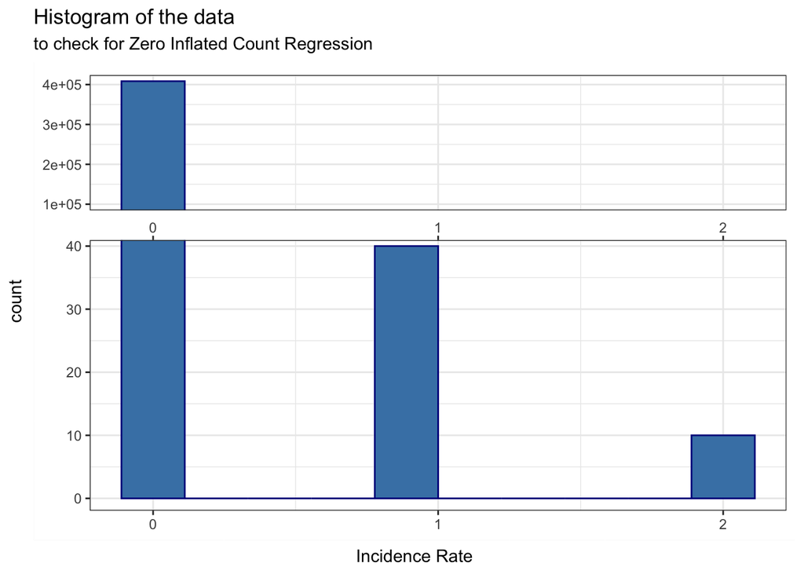

```
##
## Call:
## zeroinfl(formula = Donation ~ ., data = nb_data, dist = "negbin", link = "logit")
##
## Pearson residuals:
##        Min         1Q     Median         3Q        Max
## -0.0482124 -0.0095737 -0.0040809 -0.0008748 54.2900591
##
## Count model coefficients (negbin with log link):
##              Estimate Std. Error z value Pr(>|z|)
## (Intercept) 127.53280         NA      NA       NA
## Year         -0.11890         NA      NA       NA
## Rainfall     -0.05938         NA      NA       NA
## Temperature   1.38393         NA      NA       NA
## Humidity      1.22883         NA      NA       NA
## Value        -0.04022         NA      NA       NA
## Log(theta)   22.71629         NA      NA       NA
##
## Zero-inflation model coefficients (binomial with logit link):
##               Estimate Std. Error z value Pr(>|z|)
## (Intercept) -891.10480         NA      NA       NA
## Year           0.39012         NA      NA       NA
## Rainfall      -0.06204         NA      NA       NA
## Temperature    1.41941         NA      NA       NA
## Humidity       1.27037         NA      NA       NA
## Value         12.10767         NA      NA       NA
##
## Theta = 7337724114.4553
## Number of iterations in BFGS optimization: 107
## Log-likelihood: -447.8 on 13 Df
```

# Conclusion stats

```
##              df       AIC
## zinb         13  921.6213
## negb_all      7 1004.3325
## negb_weather  6 1060.1398
## negb          3 1066.2090
## pois          2 1196.0311
```

```
## [1] "Dispersion Parameter 0.000500178893725912"
```

```
## [1] "Null Deviance 282.709523021868"
```

```
## [1] "Residual Deviance 215.986567788402"
```

```
## [1] "Degree of Freedom 408474"
```

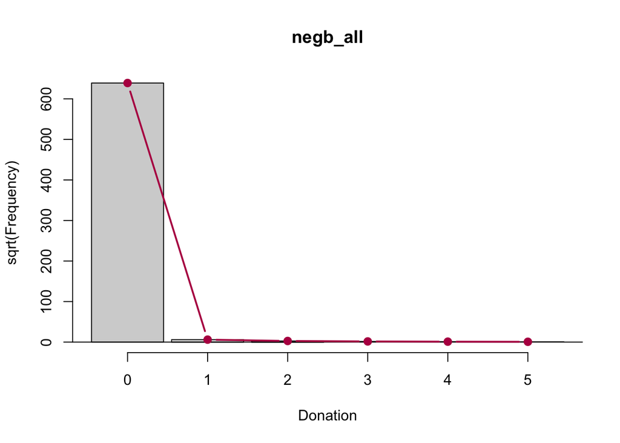